# Empirical Analysis of Put-Call Parity on PepsiCo Options

**Goal:** Demonstrate how put-call parity links theoretical Black-Scholes prices to market option quotes using PepsiCo (PEP) as the underlying stock.

**Approach**

1. **Stock context**: Reviewed Pepsi's price history and log returns as of September 11, 2025.
2. **Theoretical parity**: Verified that $C - P = S e^{-qT} - K e^{-rT}$  
   holds under the Black-Scholes model with dividends across a range of strikes.
3. **Market parity**: Pulled the option chain expiring September 12, 2025, computed $C-P$ from mid quotes, and compared observed deviations against a bid-ask tolerance band.

**Key choices**

- This notebook was run **after market hours on September 11, 2025**, which automatically synced ASOF to that date and selected the nearest expiry (**September 12, 2025**). Running after hours pulls **end-of-day prices** and option quotes, which avoids intraday noise and ensures reproducibility of figures.
- Applied continuous compounding rates $(r, q)$, with dividend yield $q$ on the stock leg.
- End-of-day option chain data showed consistent pricing, with no major issues from illiquidity or missing quotes.

```python
#Parameters for Put-Call Parity Analysis

#Imports
import numpy as np
import pandas as pd
import yfinance as yf
import matplotlib.pyplot as plt
from datetime import datetime, timedelta
from scipy.stats import norm

#Underlying stock ticker
TICKER = "PEP"

#Financial parameters (annualized, continuous compounding)
r = 0.044   #risk-free rate chosen based on US 3-month treasury yield as of Sept 2025
q = 0.0365  #PepsiCo's forward annual dividend yield from Yahoo Finance as of Sept 2025

#Plotting defaults
plt.rcParams["figure.figsize"] = (9, 4.5)

#Sync to live market
tk = yf.Ticker(TICKER)

#Latest trading day & close for spot price
_hist = tk.history(period="5d")
_hist.index = pd.to_datetime(_hist.index).tz_localize(None) if _hist.index.tz is not None else pd.to_datetime(_hist.index)
ASOF = _hist.index[-1].strftime("%Y-%m-%d")
S0   = float(_hist["Close"].iloc[-1])

#Nearest available option expiry
_opts = tk.options
EXPIRY = _opts[0]

print("Configuration loaded (live sync):")
print(f" TICKER = {TICKER}")
print(f" ASOF   = {ASOF}")
print(f" S0     = {S0:.4f}")
print(f" EXPIRY = {EXPIRY}")
print(f" r      = {r}")
print(f" q      = {q}")
```

```
Configuration loaded (live sync):
 TICKER = PEP
 ASOF   = 2025-09-11
 S0     = 144.2300
 EXPIRY = 2025-09-12
 r      = 0.044
 q      = 0.0365
```

## Part 1: Stock Context (Price & Log Returns)

**Motivation:** Options pricing depends on the behavior of the underlying stock. Reviewing Pepsi’s recent price history and return patterns provided necessary context for interpreting option chain results.

**Method:** Collected one year of daily prices up to September 11, 2025 (ASOF date) and computed log returns. Visualized both the price level and the series of daily log returns to capture volatility patterns.

```python
#Part 1: Stock Context (Price & Log Returns)

from datetime import datetime, timedelta
import numpy as np
import pandas as pd
import yfinance as yf
import matplotlib.pyplot as plt

plt.rcParams["figure.figsize"] = (9, 4.5)

#Remove time zone for safe datetime comparisons
def _drop_tz(df: pd.DataFrame) -> pd.DataFrame:
    if not isinstance(df.index, pd.DatetimeIndex):
        return df
    try:
        df = df.copy()
        df.index = df.index.tz_localize(None)   #works if tz-aware
    except TypeError:
        #already tz-naive; nothing to do
        pass
    return df

#Retrieve Pepsi's spot price (S0) as of the pinned ASOF date.
#If the date is not a trading day, the function falls back to the most recent close.
def get_spot_asof(ticker: str, asof_str: str) -> float:
    asof = datetime.fromisoformat(asof_str)
    start = (asof - timedelta(days=7)).strftime("%Y-%m-%d")
    end   = (asof + timedelta(days=1)).strftime("%Y-%m-%d")
    hist = yf.Ticker(ticker).history(start=start, end=end)
    hist = _drop_tz(hist)
    cutoff = pd.to_datetime(asof_str)          #tz-naive cutoff
    hist = hist[hist.index <= cutoff]
    if hist.empty:
        raise ValueError("No close found on/before ASOF; adjust ASOF/window.")
    return float(hist["Close"].iloc[-1])

S0 = get_spot_asof(TICKER, ASOF)
print(f"{TICKER} spot as of {ASOF}: S0 = {S0:.4f}")

#Collect one year of daily closes leading up to ASOF.
#This provides historical context for option pricing and volatility analysis.
UNDERLYING_CTX_YEARS = 1
asof_dt = datetime.fromisoformat(ASOF)
start = (asof_dt - timedelta(days=365 * UNDERLYING_CTX_YEARS + 10)).strftime("%Y-%m-%d")
end   = (asof_dt + timedelta(days=1)).strftime("%Y-%m-%d")

hist = yf.Ticker(TICKER).history(start=start, end=end)
hist = _drop_tz(hist)
cutoff = pd.to_datetime(ASOF)
hist = hist[hist.index <= cutoff].copy()

#Compute daily log returns to capture volatility patterns.
hist["LogRet"] = np.log(hist["Close"]).diff()
```

```
PEP spot as of 2025-09-11: S0 = 144.2300
```

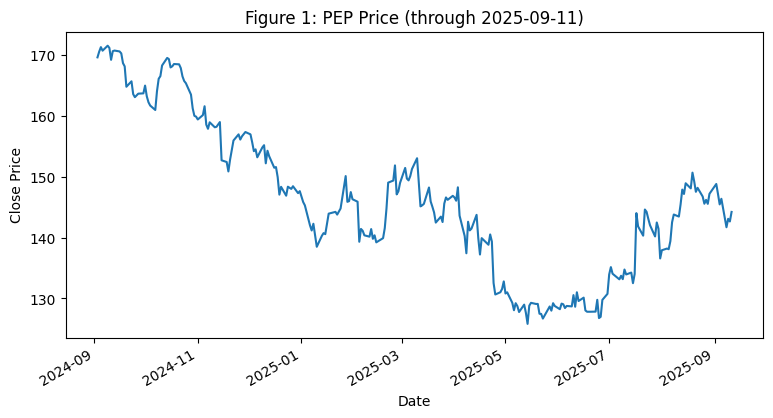

```python
#Plot the stock price series up to ASOF.
ax = hist["Close"].plot(title = f"Figure 1: {TICKER} Price (through {ASOF})")
ax.set_xlabel("Date")
ax.set_ylabel("Close Price")
plt.show()
```

**Interpretation:** Figure 1 shows us that PepsiCo's spot price $(S_0)$ was $144.23 on September 11, 2025. Over the last year, the stock declined from highs above 170 in late 2024 to lows near 125 by mid-2025, before partially rebounding. This trend highlights both sustained weakness and some recovery momentum in the underlying asset.

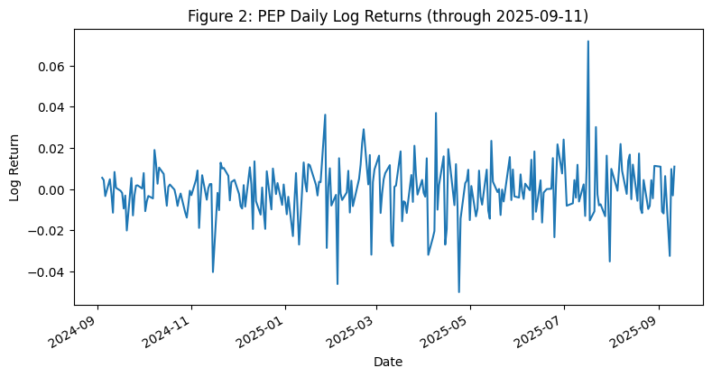

```python
#Plot daily log returns to highlight volatility bursts.
ax = hist["LogRet"].plot(title = f"Figure 2: {TICKER} Daily Log Returns (through {ASOF})")
ax.set_xlabel("Date")
ax.set_ylabel("Log Return")
plt.show()
```

## Part 2: Theoretical Put-Call Parity (Black-Scholes with dividends)

**Motivation:** Before testing against market data, it is important to confirm that put-call parity holds in theory. This ensures our implementation of Black-Scholes pricing with dividends is consistent and that any later deviations reflect market conditions, not coding errors. We will verify that the parity relation holds to within numerical precision, which in this case is on the order of $10^{-14}$.

**Method:** Calculated the year fraction between September 11, 2025 (ASOF date) and September 12, 2025 (expiry). Using Pepsi's spot price and fixed values for the risk-free rate and dividend yield, priced calls and puts across a range of strikes with Black-Scholes. Then compared the left-hand ($C-P$) and right-hand ($S e^{-qT} - K e^{-rT}$) sides of the parity relation across strikes.

|  | strike | C | P | lhs_C_minus_P | rhs_Se_qT_minus_Ke_rT | diff |
| --- | --- | --- | --- | --- | --- | --- |
| 0 | 100.960997 | 43.266746 | 3.792601e-165 | 43.266746 | 43.266746 | 0.0 |
| 1 | 104.566747 | 39.661431 | 7.259740e-135 | 39.661431 | 39.661431 | 0.0 |
| 2 | 108.172497 | 36.056116 | 1.444674e-108 | 36.056116 | 36.056116 | 0.0 |
| 3 | 111.778247 | 32.450801 | 6.828843e-86 | 32.450801 | 32.450801 | 0.0 |
| 4 | 115.383997 | 28.845485 | 1.599496e-66 | 28.845485 | 28.845485 | 0.0 |
| 5 | 118.989746 | 25.240170 | 3.582602e-50 | 25.240170 | 25.240170 | 0.0 |
| 6 | 122.595496 | 21.634855 | 1.385891e-36 | 21.634855 | 21.634855 | 0.0 |
| 7 | 126.201246 | 18.029540 | 1.581920e-25 | 18.029540 | 18.029540 | 0.0 |

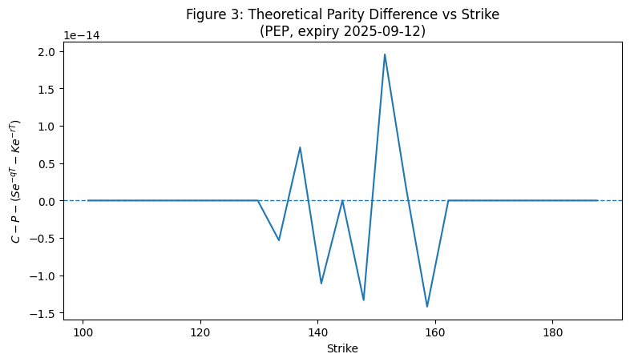

```
[Part 2] Max |parity diff| across strikes (theory): 1.954e-14 (numerical precision)
```

```python
#Part 2: Theoretical Put–Call Parity (Black–Scholes with dividends)

import numpy as np
import pandas as pd
import matplotlib.pyplot as plt
from datetime import datetime

#Year fraction (ACT/365) between ASOF and EXPIRY for pricing horizon T
def yearfrac(asof_str: str, expiry_str: str) -> float:
    asof = datetime.fromisoformat(asof_str)
    exp  = datetime.fromisoformat(expiry_str)
    return (exp - asof).days / 365.0

T = yearfrac(ASOF, EXPIRY)

#Black–Scholes European call/put with continuous dividend yield q
def bs_call_put(S: float, K: float, r: float, q: float, T: float, sigma: float):
    """
    Returns (C, P) under Black–Scholes with continuous dividend yield q.
    Note: Volatility affects C and P but not whether the parity identity holds.
    """
    if T <= 0 or sigma <= 0 or S <= 0 or K <= 0:
        return (np.nan, np.nan)
    d1 = (np.log(S / K) + (r - q + 0.5 * sigma**2) * T) / (sigma * np.sqrt(T))
    d2 = d1 - sigma * np.sqrt(T)
    C  = S * np.exp(-q * T) * norm.cdf(d1) - K * np.exp(-r * T) * norm.cdf(d2)
    P  = K * np.exp(-r * T) * norm.cdf(-d2) - S * np.exp(-q * T) * norm.cdf(-d1)
    return (C, P)

#Build a strike grid around S0 and evaluate parity components under BS
SIGMA_THEORY = 0.25  #placeholder volatility for pricing visualization
K_grid = np.linspace(0.7 * S0, 1.3 * S0, 25)

rows = []
for K in K_grid:
    C, P = bs_call_put(S0, K, r, q, T, SIGMA_THEORY)
    lhs = C - P
    rhs = S0 * np.exp(-q * T) - K * np.exp(-r * T)
    rows.append({
        "strike": K,
        "C": C, "P": P,
        "lhs_C_minus_P": lhs,
        "rhs_Se_qT_minus_Ke_rT": rhs,
        "diff": lhs - rhs
    })

df_theory = pd.DataFrame(rows).sort_values("strike")
display(df_theory.head(8))

#Plot parity difference vs strike.
#This should be ~0 up to numerical precision.
fig, ax = plt.subplots()
ax.axhline(0.0, linestyle="--", linewidth=1)
ax.plot(df_theory["strike"], df_theory["diff"])
ax.set_title(f"Figure 3: Theoretical Parity Difference vs Strike\n({TICKER}, expiry {EXPIRY})")
ax.set_xlabel("Strike")
ax.set_ylabel(r"$C - P - (S e^{-qT} - K e^{-rT})$")
plt.show()

#Summary printout for the notebook log
max_abs_diff = float(df_theory["diff"].abs().max())
print(f"[Part 2] Max |parity diff| across strikes (theory): {max_abs_diff:.3e} (numerical precision)")
```

**Interpretation (Graph):** Figure 3 shows us the parity residuals across strikes for Pepsi options expiring September 12, 2025. The residuals remain flat at zero across the grid, with the maximum deviation about $1.95 \times 10^{-14}$. This confirms that under Black-Scholes with dividends, put-call parity holds exactly in theory, and any deviations later must come from real-world market frictions.

## Part 3: Market Put-Call Parity

**Motivation:** After confirming parity in theory, the next step is to see how well it lines up with actual quotes. Any differences mainly reflect trading frictions like bid-ask, stale prints, or illiquidity.

**Method:** Pulled the live option chain for PEP from September 11, 2025 with expiration on September 12, 2025. Computed mid prices for calls and puts at each strike ($C_{mid} - P_{mid}$) and compared it to the theoretical right side ($S e^{-qT} - K e^{-rT}$). The orange dotted line represents the upper tolerance (+ band) and the green dotted line the lower tolerance (- band), which are the sum of call and put half-spreads.

|  | strike | C_mid | C_halfspread | P_mid | P_halfspread | lhs_mid | rhs_theory | diff | band |
| --- | --- | --- | --- | --- | --- | --- | --- | --- | --- |
| 0 | 110.0 | 34.750 | 1.600 | 0.555 | 0.555 | 34.195 | 34.228833 | -0.033833 | 2.155 |
| 1 | 128.0 | 17.200 | 1.050 | 0.020 | 0.010 | 17.180 | 16.231003 | 0.948997 | 1.060 |
| 2 | 132.0 | 13.275 | 1.125 | 0.020 | 0.020 | 13.255 | 12.231485 | 1.023515 | 1.145 |
| 3 | 133.0 | 12.250 | 1.100 | 0.050 | 0.040 | 12.200 | 11.231605 | 0.968395 | 1.140 |
| 4 | 134.0 | 10.800 | 1.550 | 0.155 | 0.155 | 10.645 | 10.231726 | 0.413274 | 1.705 |
| 5 | 135.0 | 10.100 | 0.950 | 0.040 | 0.030 | 10.060 | 9.231846 | 0.828154 | 0.980 |
| 6 | 136.0 | 7.825 | 0.625 | 0.095 | 0.085 | 7.730 | 8.231967 | -0.501967 | 0.710 |
| 7 | 138.0 | 7.250 | 1.100 | 0.140 | 0.130 | 7.110 | 6.232208 | 0.877792 | 1.230 |
| 8 | 139.0 | 5.725 | 0.525 | 0.035 | 0.035 | 5.690 | 5.232329 | 0.457671 | 0.560 |
| 9 | 140.0 | 4.775 | 0.575 | 0.090 | 0.050 | 4.685 | 4.232449 | 0.452551 | 0.625 |

```
Calls both-zero: 0 / 30
Puts  both-zero: 0 / 37
```

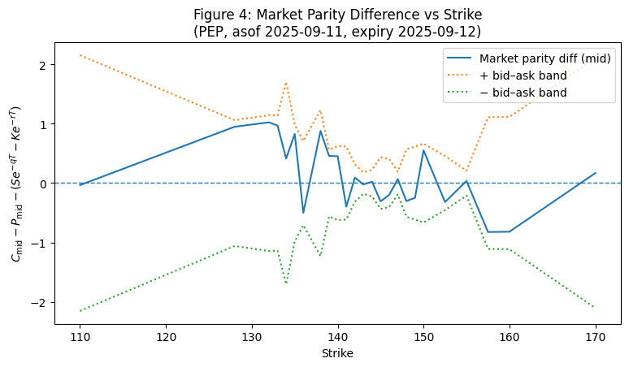

```python
#Part 3: Market Put-Call Parity

T = yearfrac(ASOF, EXPIRY)
tk = yf.Ticker(TICKER)

#Pull option chain (calls & puts) for the chosen live expiry
chain = tk.option_chain(EXPIRY)
calls_raw = chain.calls.copy()
puts_raw  = chain.puts.copy()

#Raw mids
calls_raw["C_mid"] = (calls_raw["bid"] + calls_raw["ask"]) / 2.0
puts_raw["P_mid"]  = (puts_raw["bid"]  + puts_raw["ask"])  / 2.0

#Half-spreads for a visual tolerance band
calls_raw["C_halfspread"] = (calls_raw["ask"] - calls_raw["bid"]) / 2.0
puts_raw["P_halfspread"]  = (puts_raw["ask"]  - puts_raw["bid"])  / 2.0

#Merge by strike
m = pd.merge(
    calls_raw[["strike", "C_mid", "C_halfspread"]],
    puts_raw[["strike", "P_mid", "P_halfspread"]],
    on="strike", how="inner"
).sort_values("strike")

#Parity components
m["lhs_mid"] = m["C_mid"] - m["P_mid"]
m["rhs_theory"] = S0 * np.exp(-q * T) - m["strike"] * np.exp(-r * T)
m["diff"] = m["lhs_mid"] - m["rhs_theory"]
m["band"] = (m["C_halfspread"] + m["P_halfspread"]).astype(float)

#Quick peek + zero stats
display(m.head(10))
both_zero_calls = ((calls_raw["bid"]==0) & (calls_raw["ask"]==0)).sum()
both_zero_puts  = ((puts_raw["bid"]==0)  & (puts_raw["ask"]==0)).sum()
print(f"Calls both-zero: {both_zero_calls} / {len(calls_raw)}")
print(f"Puts  both-zero: {both_zero_puts} / {len(puts_raw)}")

#Plot raw parity deviation vs strike with bid–ask band
fig, ax = plt.subplots()
ax.axhline(0.0, linestyle="--", linewidth=1)
ax.plot(m["strike"], m["diff"], label="Market parity diff (mid)")
ax.plot(m["strike"],  m["band"], linestyle=":", label="+ bid–ask band")
ax.plot(m["strike"], -m["band"], linestyle=":", label="− bid–ask band")
ax.set_title(f"Figure 4: Market Parity Difference vs Strike\n({TICKER}, asof {ASOF}, expiry {EXPIRY})")
ax.set_xlabel("Strike")
ax.set_ylabel(r"$C_{\mathrm{mid}} - P_{\mathrm{mid}} - (S e^{-qT} - K e^{-rT})$")
ax.legend()
plt.show()
```

**Interpretation (Table):** The preview table lists strikes, mid call and put prices, half-spreads, the theoretical parity RHS, and the difference. Most `diff` values are close to zero but not exact, since the market introduces frictions like bid-ask spreads. The `band` column shows the tolerance range implied by these spreads.

**Interpretation (Graph):** Figure 4 shows us the market parity differences across strikes for Pepsi options expiring September 12, 2025. The solid blue line (mid-market diff) fluctuates around zero, while the orange dotted line (upper tolerance) and green dotted line (lower tolerance) capture the bid-ask band. Since the blue line stays between the orange and green bands, the market is consistent with put-call parity. This means that apparent “violations” are explained by normal trading frictions rather than true arbitrage.

## Conclusion

**Project Findings:** This analysis verified put-call parity on PepsiCo options from September 11-12, 2025.

- In Part 1, we reviewed Pepsi's price history and daily log returns, establishing context for option valuation.
- In Part 2, we found that theoretical parity holds to numerical precision, confirming that the Black-Scholes model with dividends enforced the relationship exactly.
- In Part 3, we compared theoretical put-call parity to live market quotes. The observed differences fluctuated around zero but remained within the tolerance band implied by bid-ask spreads.

**Interpretation:** Since the blue line (market diff) stayed between the orange and green dotted bands, the market is consistent with put-call parity once transaction costs are considered. If the blue line had fallen outside these bands, that would signal a potential arbitrage opportunity to construct a risk-free profit by trading stock, calls, and puts. In practice, however, such violations are rare and fleeting. They are usually eliminated quickly by market makers or high-frequency traders, or absorbed into wider spreads that reflect trading frictions.

**Takeaway:** Pepsi's option market is consistent with put-call parity. What look like "violations" are better understood as the normal effects of transaction costs, liquidity, and spreads rather than exploitable arbitrage.